# Bey2ollak Traffic Analaysis

The Traffic dataset is collected from bey2ollak.com, This EDA summarizes some of important data features and show some of the traffic activities and patterns in Cairo.

```r
library(grid)
library(ggplot2)
library(dplyr)
library(mixtools)
```

```r
data <- read.csv("../traffic-data.csv", encoding="UTF-8")
data %>% names()
```

```
##  [1] "crawl_date"      "ad.aid"          "ad.bgcl"
##  [4] "ad.bgcls"        "ad.fncl"         "ad.fncls"
##  [7] "ad.lid"          "ad.logo"         "ad.logo2x"
## [10] "ad.logoAndroidS" "ad.logoAndroidH" "ad.cm"
## [13] "ad.url"          "ad.g"            "rd.nm"
## [16] "rd.ri"           "rd.stid"         "rd.hr"
## [19] "rd.mn"           "rd.new"          "rd.img"
## [22] "rd.cl"           "rd.strq"         "rd.cmrq"
## [25] "rd.rp.nm"        "rd.rp.fullnm"    "rd.rp.hr"
## [28] "rd.rp.mn"        "rd.rp.stid"      "rd.rp.cm"
## [31] "rd.rp.cmid"      "rd.rp.rpImg"     "rd.rp.img"
## [34] "rd.rp.type"
```

```r
data %>% nrow()
```

```
## [1] 429982
```

### Data Summary

```r
data %>% str()
```

```
## 'data.frame':    429982 obs. of  34 variables:
##  $ crawl_date     : Factor w/ 28331 levels "Fri Feb  5 17:22:54 UTC 2016",..: 48 48 48 48 4627 4627 4678 4678 4731 4731 ...
##  $ ad.aid         : int  2538 2538 2538 2538 2538 2538 2538 2538 2538 2538 ...
##  $ ad.bgcl        : Factor w/ 1 level "#003768": 1 1 1 1 1 1 1 1 1 1 ...
##  $ ad.bgcls       : Factor w/ 1 level "#0069aa": 1 1 1 1 1 1 1 1 1 1 ...
##  $ ad.fncl        : Factor w/ 1 level "#FFFFFF": 1 1 1 1 1 1 1 1 1 1 ...
##  $ ad.fncls       : Factor w/ 1 level "#FFFFFF": 1 1 1 1 1 1 1 1 1 1 ...
##  $ ad.lid         : int  1001 1001 1001 1001 1001 1001 1001 1001 1001 1001 ...
##  $ ad.logo        : Factor w/ 1 level "http://www.bey2ollak.com/downloads/logos/Pepsi_SA7EL.png": 1 1 1 1 1 1 1 1 1 1 ...
##  $ ad.logo2x      : Factor w/ 1 level "http://www.bey2ollak.com/downloads/logos/Pepsi_SA7EL@2x.png": 1 1 1 1 1 1 1 1 1 1 ...
##  $ ad.logoAndroidS: Factor w/ 1 level "http://www.bey2ollak.com/downloads/logos/Pepsi_SA7EL_ANDROID_S.png": 1 1 1 1 1 1 1 1 1 1 ...
##  $ ad.logoAndroidH: Factor w/ 1 level "http://www.bey2ollak.com/downloads/logos/Pepsi_SA7EL_ANDROID_H.png": 1 1 1 1 1 1 1 1 1 1 ...
##  $ ad.cm          : Factor w/ 1 level "دوس هنا وشوف إعلان بيبسي الجديد مع محمد صلاح #يلا_تقدر": 1 1 1 1 1 1 1 1 1 1 ...
##  $ ad.url         : Factor w/ 1 level "http://youtu.be/aNeqShdgupY": 1 1 1 1 1 1 1 1 1 1 ...
##  $ ad.g           : int  1 1 1 1 1 1 1 1 1 1 ...
```

[output cut: 20 more lines]

```r
data %>% summary()
```

```
##                         crawl_date         ad.aid        ad.bgcl
##  Sun Feb  7 22:30:11 UTC 2016:   120   Min.   :2538   #003768:429982
##  Sun Feb  7 22:30:13 UTC 2016:   120   1st Qu.:2538
##  Sun Feb  7 22:30:14 UTC 2016:   120   Median :2538
##  Sun Feb  7 22:30:15 UTC 2016:   120   Mean   :2538
##  Sun Feb  7 22:30:18 UTC 2016:   120   3rd Qu.:2538
##  Sun Feb  7 22:30:25 UTC 2016:   120   Max.   :2538
##  (Other)                     :429262
##     ad.bgcls         ad.fncl          ad.fncls          ad.lid
##  #0069aa:429982   #FFFFFF:429982   #FFFFFF:429982   Min.   :1001
##                                                     1st Qu.:1001
##                                                     Median :1001
##                                                     Mean   :1001
##                                                     3rd Qu.:1001
##                                                     Max.   :1001
##
##                                                      ad.logo
##  http://www.bey2ollak.com/downloads/logos/Pepsi_SA7EL.png:429982
##
##
##
##
##
##
##                                                        ad.logo2x
##  http://www.bey2ollak.com/downloads/logos/Pepsi_SA7EL@2x.png:429982
##
##
##
##
##
##
##                                                            ad.logoAndroidS
##  http://www.bey2ollak.com/downloads/logos/Pepsi_SA7EL_ANDROID_S.png:429982
##
##
##
##
##
##
```

[output cut: 57 more lines]

```
##  Min.   : 0.0   Min.   : 1.00   lazeez       : 76106   Min.   :9271509
##  1st Qu.:14.0   1st Qu.: 2.00   mashy        : 21710   1st Qu.:9338581
##  Median :29.0   Median : 3.00   7alawa       : 16996   Median :9376096
##  Mean   :29.2   Mean   : 4.71   za7ma        : 14183   Mean   :9376278
##  3rd Qu.:44.0   3rd Qu.:10.00   Eih el nezam?: 14127   3rd Qu.:9413977
##  Max.   :59.0   Max.   :10.00   mafeesh amal :  7904   Max.   :9452302
##                 NA's   :13965   (Other)      :278956
##   rd.rp.rpImg       rd.rp.img        rd.rp.type
##  Min.   : 21970   Min.   :    50   Min.   :0
##  1st Qu.:458600   1st Qu.: 62923   1st Qu.:0
##  Median :461455   Median : 62923   Median :0
##  Mean   :461014   Mean   :146707   Mean   :0
##  3rd Qu.:464205   3rd Qu.:233366   3rd Qu.:0
##  Max.   :467309   Max.   :467247   Max.   :0
##  NA's   :411585   NA's   :152557
```

Now we need to define the report time.

Let’s have a look on rd.rp.hr.

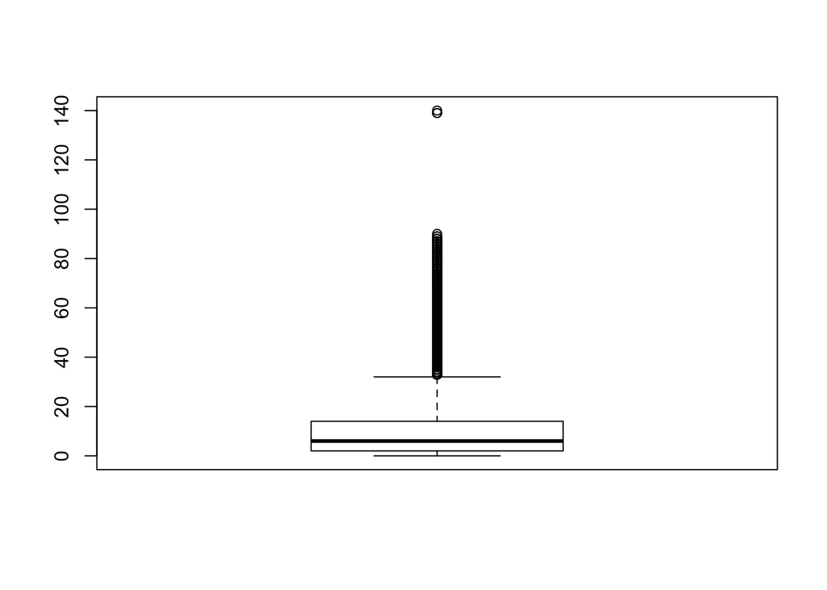

```r
data$rd.rp.hr %>% boxplot()
```

rd.rp.hr has some data above 24. Thus, we can confirm that it is the hours elapsed.

The rows represent a traffic report made on the website. The columns meaning can be extracted by looking into the website and how they use the data to render the fields. The meaning of the important columns are:

| Column Pattern | Meaning |
| --- | --- |
| crawl_date | time data was crawled |
| ad.* | information related to advertisment |
| rd.* | information related to a road |
| hr | the number of hours elapsed from the report was made to crawling date |
| mn | hr + mn gives the exact time elapased from the report date to crawling date |
| rd.rp | data related to a report |
| rd.rp.fullnm | reporter fullname |
| rp.rp.nm | reporter username |
| stid | rd.rp.stid is the status id of the report; rd.stid is the road status id |
| rd.nm | road name (; To ) |
| rd.rp.cm | user comment |
| rd.ri | road id |

Now let’s calcualte the actual report time.

```r
data$crawl_date         <- as.POSIXct(strptime(data$crawl_date, format="%A %b %d %H:%M:%S UTC %Y"), tz='UTC')
data$crawl_date         <- as.POSIXlt(data$crawl_date, tz="Africa/Cairo")
data$report_date        <- data$crawl_date
data$report_date$hour   <- (data$crawl_date$hour - data$rd.rp.hr) %% 24
data$report_date$minute <- data$crawl_date$minute - data$rd.rp.mn
```

Now we prepare Time units for usage simplicity.

```r
data$hour <- data$report_date$hour
data$min  <- data$report_date$min
data$wday <- data$report_date$wday
data$yday <- data$report_date$yday
```

The stid columns hold report status. Let’s confirm the meaning of each id by viewing a sample of the comments for each status id.

stid = 1

```r
data[!is.na(data$rd.rp.stid) & data$rd.rp.stid == 1, c('rd.rp.stid', 'rd.rp.cm')] %>% head(10)
```

```
##     rd.rp.stid rd.rp.cm
## 6            1   7alawa
## 8            1   7alawa
## 10           1   7alawa
## 207          1   7alawa
## 208          1   7alawa
## 209          1   7alawa
## 255          1   7alawa
## 256          1   7alawa
## 257          1   7alawa
## 261          1   7alawa
```

stid = 2

```r
data[!is.na(data$rd.rp.stid) & data$rd.rp.stid == 2, c('rd.rp.stid', 'rd.rp.cm')] %>% head(10)
```

```
##    rd.rp.stid rd.rp.cm
## 1           2   lazeez
## 2           2   lazeez
## 3           2   lazeez
## 4           2   lazeez
## 5           2   lazeez
## 7           2   lazeez
## 9           2   lazeez
## 11          2   lazeez
## 12          2   lazeez
## 13          2   lazeez
```

stid = 3

```r
data[!is.na(data$rd.rp.stid) & data$rd.rp.stid == 3, c('rd.rp.stid', 'rd.rp.cm')] %>% head(10)
```

```
##    rd.rp.stid                                          rd.rp.cm
## 17          3     الطريق أخد حوالي [4 ق] ومتوسط سرعته [23 كم/س]
## 18          3 Overall took [4 min] with average speed [23 km/h]
## 20          3     الطريق أخد حوالي [4 ق] ومتوسط سرعته [23 كم/س]
## 21          3 Overall took [4 min] with average speed [23 km/h]
## 23          3                                             mashy
## 24          3     الطريق أخد حوالي [4 ق] ومتوسط سرعته [23 كم/س]
## 25          3 Overall took [4 min] with average speed [23 km/h]
## 27          3                                             mashy
## 28          3                                             mashy
## 51          3                                             mashy
```

stid = 4

```r
data[!is.na(data$rd.rp.stid) & data$rd.rp.stid == 4, c('rd.rp.stid', 'rd.rp.cm')] %>% head(10)
```

```
##     rd.rp.stid rd.rp.cm
## 102          4    awelo
## 103          4    awelo
## 104          4    za7ma
## 105          4    awelo
## 106          4    za7ma
## 107          4    za7ma
## 108          4    za7ma
## 109          4    za7ma
## 110          4    za7ma
## 111          4    za7ma
```

stid = 5

```r
data[!is.na(data$rd.rp.stid) & data$rd.rp.stid == 5, c('rd.rp.stid', 'rd.rp.cm')] %>% head(10)
```

```
##     rd.rp.stid                              rd.rp.cm
## 479          5                          mafeesh amal
## 480          5             زحمه لحد فين  ياريت السبب
## 481          5                           za7ma gedan
## 493          5                          mafeesh amal
## 495          5 etl3o october mn 3'amra,, mtkmlsh t7t
## 499          5                          mafeesh amal
## 501          5                          mafeesh amal
## 502          5                    what's wrong today
## 503          5                          mafeesh amal
## 504          5                                 avoid
```

stid = 6

```r
data[!is.na(data$rd.rp.stid) & data$rd.rp.stid == 6, c('rd.rp.stid', 'rd.rp.cm')] %>% head(10)
```

```
##     rd.rp.stid              rd.rp.cm
## 50           6         Eih el nezam?
## 52           6         Eih el nezam?
## 54           6         Eih el nezam?
## 475          6         Eih el nezam?
## 476          6         Eih el nezam?
## 477          6      الزحمه منين لفين
## 483          6 za7ma wla kwyyes ????
## 487          6          update plz ?
## 488          6           ايه الاخبار
## 500          6         Eih el nezam?
```

stid = 7

```r
data[!is.na(data$rd.rp.stid) & data$rd.rp.stid == 7, c('rd.rp.stid', 'rd.rp.cm')] %>% head(10)
```

```
##       rd.rp.stid
## 1228           7
## 20320          7
## 20345          7
## 20369          7
## 21912          7
## 21914          7
## 21922          7
## 21924          7
## 21937          7
## 21939          7
##                                                                                                             rd.rp.cm
## 1228  khatar-avoid mtla3 ghamra, cops are blocking it we bynazlo el nas mahmasha egbay we mahmasha is total disaster
## 20320                         khatar-حادثة عند كارفور موقفة الطريق من بعد دار السلام خدوا بالكم هيسمع عندكم بعد شوية
## 20345                         khatar-حادثة عند كارفور موقفة الطريق من بعد دار السلام خدوا بالكم هيسمع عندكم بعد شوية
## 20369                         khatar-حادثة عند كارفور موقفة الطريق من بعد دار السلام خدوا بالكم هيسمع عندكم بعد شوية
## 21912                                                                                                   khatar-رادار
## 21914                                                                                                   khatar-radar
## 21922                                                                                                   khatar-رادار
## 21924                                                                                                   khatar-radar
## 21937                                                                                                   khatar-رادار
## 21939                                                                                                   khatar-radar
```

stid = 8

```r
data[!is.na(data$rd.rp.stid) & data$rd.rp.stid == 8, c('rd.rp.stid', 'rd.rp.cm')] %>% head(10)
```

```
##      rd.rp.stid
## 4032          8
## 4037          8
## 4043          8
## 5560          8
## 5593          8
## 5621          8
## 6792          8
## 6823          8
## 6848          8
## 7442          8
##                                                                             rd.rp.cm
## 4032                                                                           7adsa
## 4037                                                                           7adsa
## 4043                                                                           7adsa
## 5560 7adsa-عربيه مقلوبه علي الدائري اتجاه الاوتوستراد وحاولوا تنزلوا من منزل المعادي
## 5593 7adsa-عربيه مقلوبه علي الدائري اتجاه الاوتوستراد وحاولوا تنزلوا من منزل المعادي
## 5621 7adsa-عربيه مقلوبه علي الدائري اتجاه الاوتوستراد وحاولوا تنزلوا من منزل المعادي
## 6792                                                                           7adsa
## 6823                                                                           7adsa
## 6848                                                                           7adsa
## 7442                                                   7adsa-10 min to pass el zahma
```

stid = 9

```r
data[!is.na(data$rd.rp.stid) & data$rd.rp.stid == 9, c('rd.rp.stid', 'rd.rp.cm')] %>% head(10)
```

```
##       rd.rp.stid
## 4552           9
## 4555           9
## 4558           9
## 5855           9
## 5877           9
## 5893           9
## 7243           9
## 7267           9
## 7291           9
## 13340          9
##                                                                        rd.rp.cm
## 4552                                   3otl-عربية عطلاتة علي الشمال عند سن سيتي
## 4555                                   3otl-عربية عطلاتة علي الشمال عند سن سيتي
## 4558                                   3otl-عربية عطلاتة علي الشمال عند سن سيتي
## 5855                                          3otl-ع الشمال...عند النزلة الأولى
## 5877                                          3otl-ع الشمال...عند النزلة الأولى
## 5893                                          3otl-ع الشمال...عند النزلة الأولى
## 7243  3otl-3arabeyya nos na2l 3atlana fel awwel fel 7ara elli fel nos take care
## 7267  3otl-3arabeyya nos na2l 3atlana fel awwel fel 7ara elli fel nos take care
## 7291  3otl-3arabeyya nos na2l 3atlana fel awwel fel 7ara elli fel nos take care
## 13340                                                  3otl-اصلاحات بعد المزرعة
```

stid = 10

```r
data[!is.na(data$rd.rp.stid) & data$rd.rp.stid == 10, c('rd.rp.stid', 'rd.rp.cm')] %>% head(10)
```

```
##      rd.rp.stid
## 482          10
## 489          10
## 793          10
## 855          10
## 876          10
## 959          10
## 1143         10
## 1175         10
## 1342         10
## 1421         10
##                                                                                 rd.rp.cm
## 482                                                                                 zeft
## 489                                                                    za7ma abl ghamra.
## 793  المرور قفل مطلع غمره علي كوبري اكتوبر و موجه كل الناس تحت علي مهمشه فطبعا مهمشه طحن
## 855                                                             مطلغ غمرة زحمة بس العادي
## 876                                                                     @Anas7afez  thnx
## 959                                                                       update  please
## 1143                                                        esharet el abaseya zahma awi
## 1175                                                                       update please
## 1342                                                                           eh elnzam
## 1421                                        howa shaklo za7ma bas it didn't take so long
```

According to the data samples and the label on the website. the stid categories are:

```r
stid <- c("7alawa", "lazez", "mashy" , "za7ma", "Noamal", "Question", "Khatar", "7adsa", "3otl", "ma3loma")
```

### Data Cleaning and Feature Engineering

First we need to remove duplicate rows

```r
data.unq <- data[!duplicated(data[, c('rd.rp.cmid')]), ]
```

Weekends. Friday and Saturday are the weekends in Egypt. Let’s use this to define a weekend row.

```r
data.weekend <- data.unq[data.unq$wday >= 5, ]
data.workday <- data.unq[data.unq$wday < 5, ]
```

We can add labels for for the city (alex or cairo) which is retrieved from an XML file from the website. The XML file contains road name and road id which I parsed with a script that saves the ids in the following csv files.

```r
cairo.roads <- read.csv("cairo-roads-ids.csv")
alex.roads <- read.csv("alex-roads-ids.csv")
cairo.roads$city = "cairo"
alex.roads$city = "alex"
data.unq <- merge(data.unq, rbind(cairo.roads, alex.roads), by="rd.ri")
```

Road names are written in a certian format as shown in the above columns definition.

```r
data.unq$rd.nm %>% sample(10)
```

```
##  [1] Kobry 6 October;Madinet Nasr To Ta7rir
##  [2] AlKasr Al3eny St.;Kornich ElNile To Midan ElTa7rir
##  [3] Sala7 Salem;Kobry 6 October To 2al3a
##  [4] Da2ery;Autostrad To Moneeb
##  [5] Da2ery;Waslet Maryoutia To Me7war
##  [6] Kornich ElNile;Arcadia To Zera3y
##  [7] AlKasr Al3eny St.;Kornich ElNile To Midan ElTa7rir
##  [8] Kobry 15 Mayo;Mohandessin To West ElBalad
##  [9] Kobry ElGam3a;Manial To Giza
## [10] Da2ery;Moneeb To Autostrad
## 301 Levels: 14 Mayo Road;Kobry 14 Mayo To Mad5al Smou7a ...
```

We can decouple the information from the road name to constrcut the source and the destination of the road.

```r
data.unq$rd.nm <- as.character(data.unq$rd.nm)
data.unq$road.name <- sapply(data.unq$rd.nm, function(x){unlist(strsplit(x, ";"))[1]})
data.unq$road.direction <- sapply(data.unq$rd.nm, function(x){unlist(strsplit(x, ";"))[2]})
data.unq$road.direction.from <- sapply(data.unq$road.direction, function(x){unlist(strsplit(x, "To"))[1]})
data.unq$road.direction.to <- sapply(data.unq$road.direction, function(x){unlist(strsplit(x, "To"))[2]})
data.unq$road.direction.from.full <- sapply(data.unq$rd.nm, function(x){unlist(strsplit(x, "To"))[1]})
```

```r
data.unq[, c("road.direction.from", "road.direction.to", "road.direction.from.full")] %>% unique() %>% head(10)
```

```
##       road.direction.from road.direction.to    road.direction.from.full
## 1            Mohandessin       West ElBalad  Kobry 15 Mayo;Mohandessin
## 1549        West ElBalad        Mohandessin Kobry 15 Mayo;West ElBalad
## 3125              Da2ery       Kornish Giza          Ba7r A3zam;Da2ery
## 3837                 <NA>              <NA>                West ElBalad
## 4478                 <NA>              <NA>                 Other Roads
## 4582           Autostrad             Moneeb           Da2ery;Autostrad
## 7580              Moneeb          Autostrad              Da2ery;Moneeb
## 10655                <NA>              <NA>                     Zamalek
## 11071                <NA>              <NA>                  Mohandesin
## 11402             Ba7ary         Sidi Gaber              ElBa7r;Ba7ary
```

Let’s have a look on the crawling distribtion per hour.

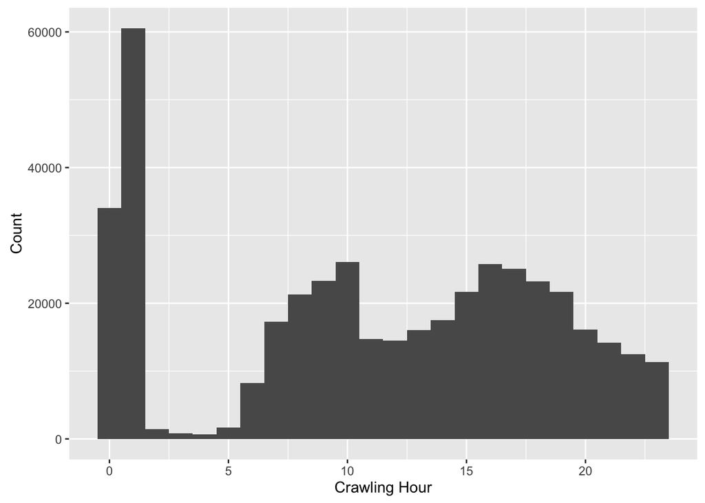

```r
qplot(data$crawl_date$hour, geom="histogram", binwidth=1, xlab = "Crawling Hour", ylab = "Count")
```

The distribution of the crawling hour cannot tell accurate information about activities.

Let’s make sure that the crawling was made continously without breaks.

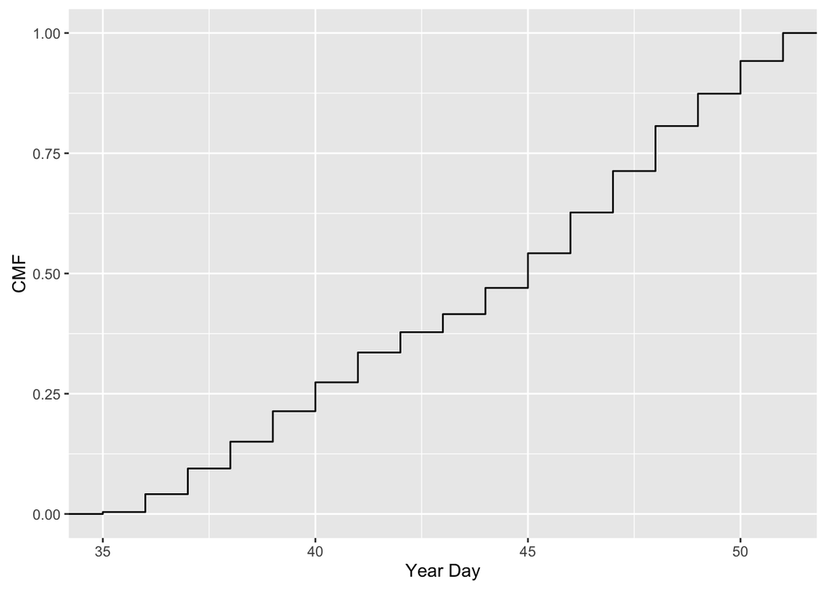

```r
ggplot(data, aes(yday)) + stat_ecdf(geom = "step") + xlab("Year Day") + ylab("CMF")
```

Luckily, There’s no obvious breaks.

Let’s focus on the important columns with respect to the scope of traffic analaysis.

```r
names.imp <- names(data.unq)
names.imp <- names.imp[!grepl("^ad", names.imp)]
data.unq <- data.unq[, names.imp]
names.imp
```

```
##  [1] "rd.ri"                    "crawl_date"
##  [3] "rd.nm"                    "rd.stid"
##  [5] "rd.hr"                    "rd.mn"
##  [7] "rd.new"                   "rd.img"
##  [9] "rd.cl"                    "rd.strq"
## [11] "rd.cmrq"                  "rd.rp.nm"
## [13] "rd.rp.fullnm"             "rd.rp.hr"
## [15] "rd.rp.mn"                 "rd.rp.stid"
## [17] "rd.rp.cm"                 "rd.rp.cmid"
## [19] "rd.rp.rpImg"              "rd.rp.img"
## [21] "rd.rp.type"               "report_date"
## [23] "hour"                     "min"
## [25] "wday"                     "yday"
## [27] "city"                     "road.name"
## [29] "road.direction"           "road.direction.from"
## [31] "road.direction.to"        "road.direction.from.full"
```

```r
data.unq %>% nrow()
```

```
## [1] 145050
```

Percentage of duplicate data

```r
1 - (nrow(data.unq) / nrow(data))
```

```
## [1] 0.6626603
```

### Activity Analaysis

Let’s have a look on the activities (reports) patterns and histograms.

Total number of activities per hour

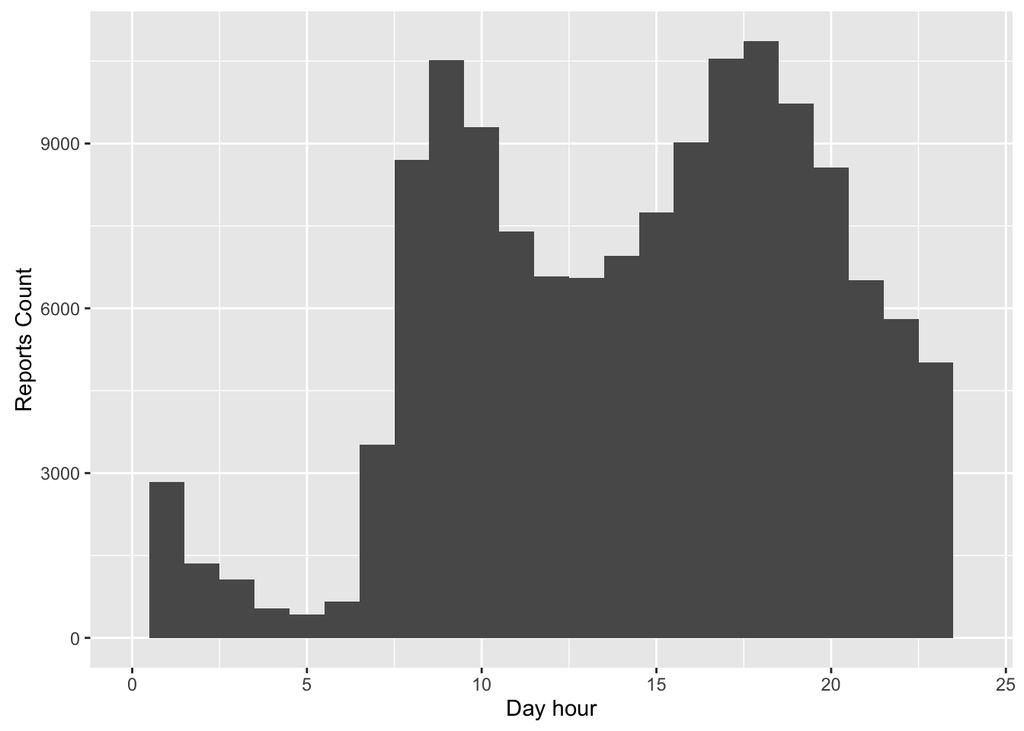

```r
qplot(data.unq$hour, geom="histogram", binwidth=1, xlim=c(0,24), xlab='Day hour', ylab='Reports Count')
```

Activities per day

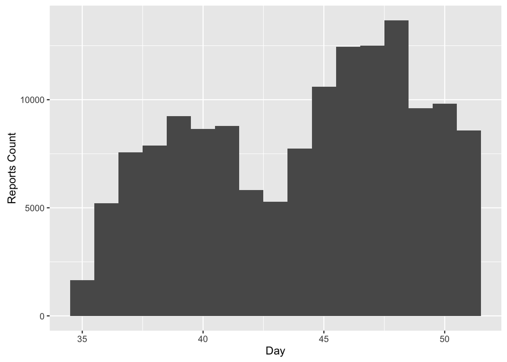

```r
qplot(data.unq$yday, geom="histogram", binwidth=1, xlab='Day', ylab='Reports Count')
```

Activities per Weekday

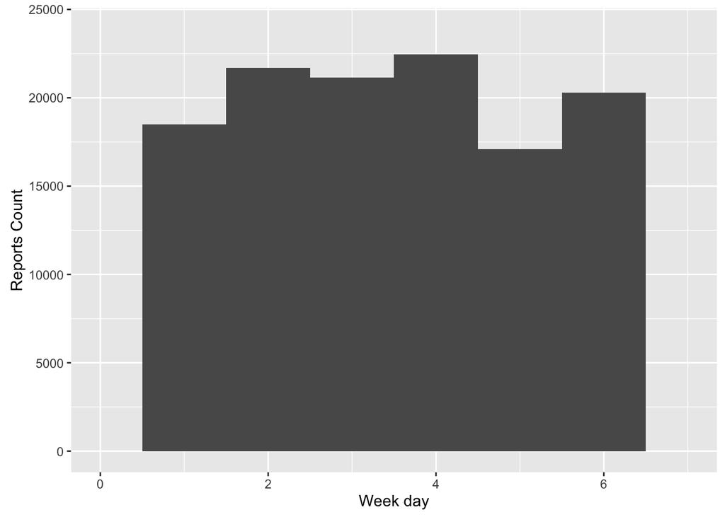

```r
qplot(data.unq$wday, geom="histogram", binwidth=1, xlim=c(0,7), xlab='Week day', ylab='Reports Count')
```

Activities per Weekdays

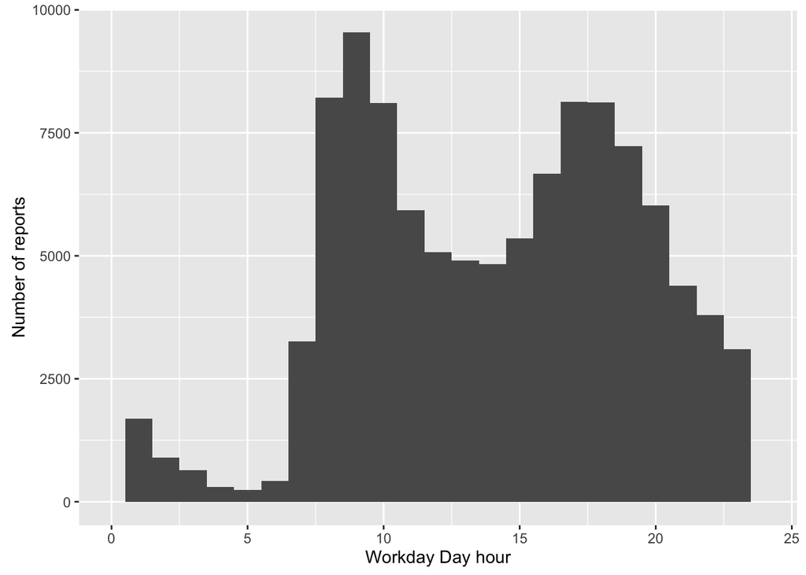

```r
qplot(data.workday$hour, geom="histogram", binwidth=1, xlim=c(0,24), xlab='Workday Day hour', ylab='Number of reports')
```

Count of each type of activity

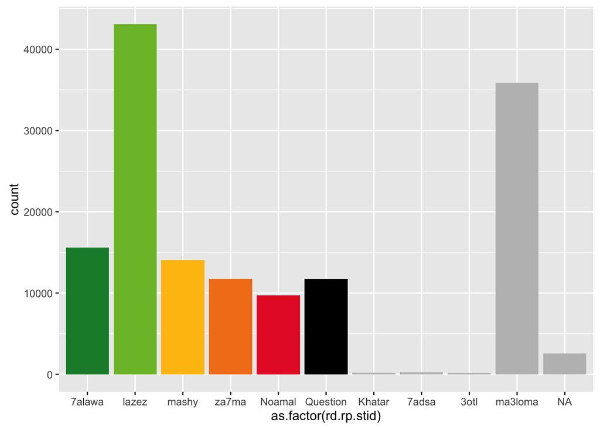

```r
p <- ggplot(data.unq , aes(as.factor(rd.rp.stid)))
p + geom_bar(fill=c("#178B37", "#7CBD33", "#FEC00D", "#F37F1B", "#E7252D", "black", "gray", "gray", "gray", "gray", "gray")) + scale_x_discrete(labels=c(stid, "NA"))
```

Count of each type of activity in Cairo only

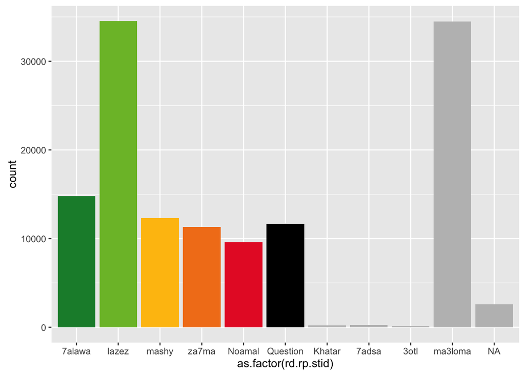

```r
p <- ggplot(data.unq[data.unq$city=="cairo",] , aes(as.factor(rd.rp.stid)))
p + geom_bar(fill=c("#178B37", "#7CBD33", "#FEC00D", "#F37F1B", "#E7252D", "black", "gray", "gray", "gray", "gray", "gray")) + scale_x_discrete(labels=c(stid, "NA"))
```

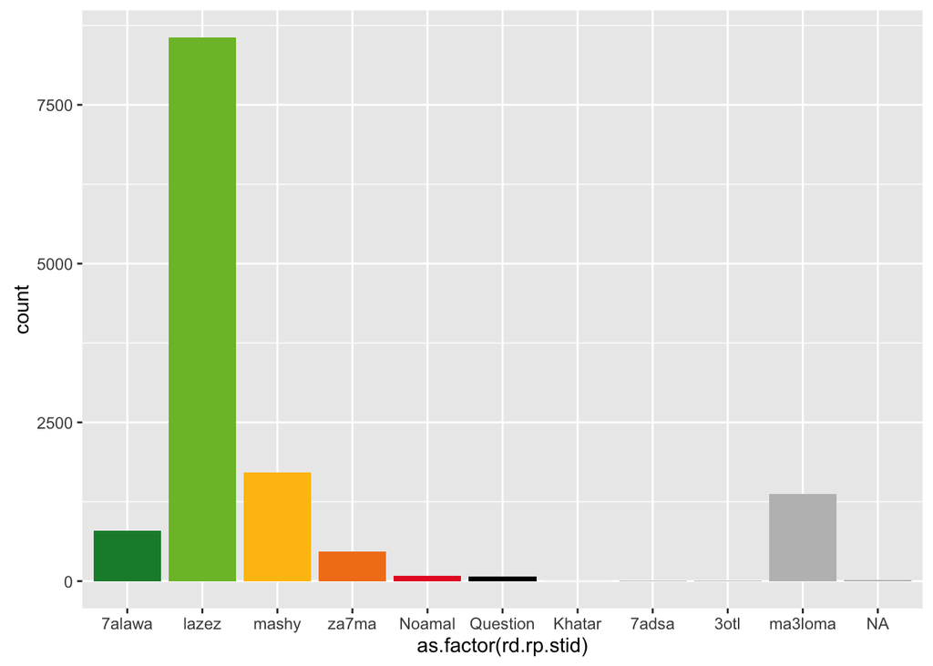

```r
p <- ggplot(data.unq[data.unq$city=="alex",] , aes(as.factor(rd.rp.stid)))
p + geom_bar(fill=c("#178B37", "#7CBD33", "#FEC00D", "#F37F1B", "#E7252D", "black", "gray", "gray", "gray", "gray", "gray")) + scale_x_discrete(labels=c(stid, "NA"))
```

Activities in alex is not huge and is biased, which does not follow the usual patterns.

## Traffic Analaysis

Road status Id indicate the traffic status of the road. we can use it to have some insights on traffic pattern.

Let’s see what is the traffic pattern per day, by plotting the stid per hour and fit a smoothing line to indicate where the is density per hour.

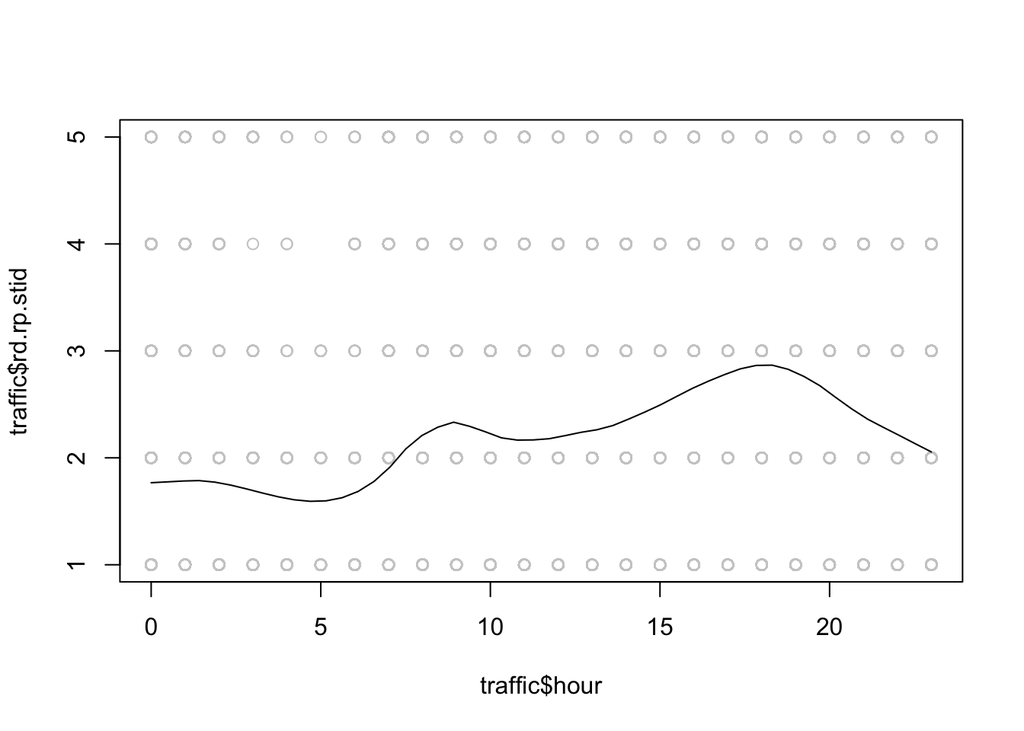

```r
traffic <- data.unq[data.unq$rd.rp.stid < 6,]
traffic <- traffic[, c("rd.rp.stid", "hour", "city")]
traffic <- na.omit(traffic)
scatter.smooth(traffic$hour, traffic$rd.rp.stid, col="#CCCCCC", span = 0.23)
```

Now Let’s compare the traffic pattern for Cairo and Alex

```r
traffic.cairo <- traffic[traffic$city == "cairo", ]
traffic.alex <- traffic[traffic$city == "alex", ]
p1 <- scatter.smooth(traffic.cairo$hour, traffic.cairo$rd.rp.stid, col="#CCCCCC", span = 0.23)
```

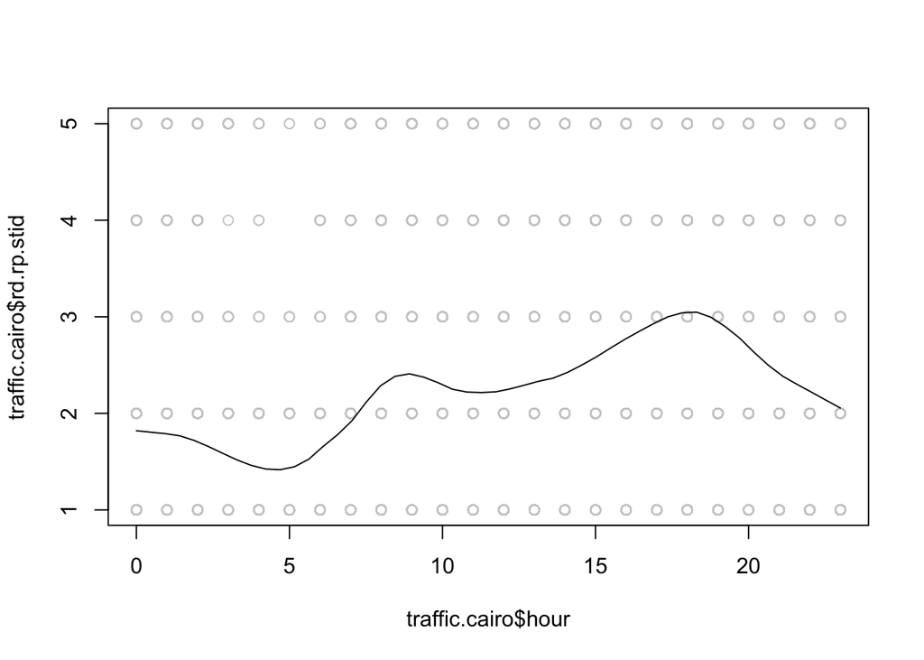

Pattern in Alex is not significant.

```r
p2 <- scatter.smooth(traffic.alex$hour, traffic.alex$rd.rp.stid, col="#CCCCCC", span = 0.23)
```

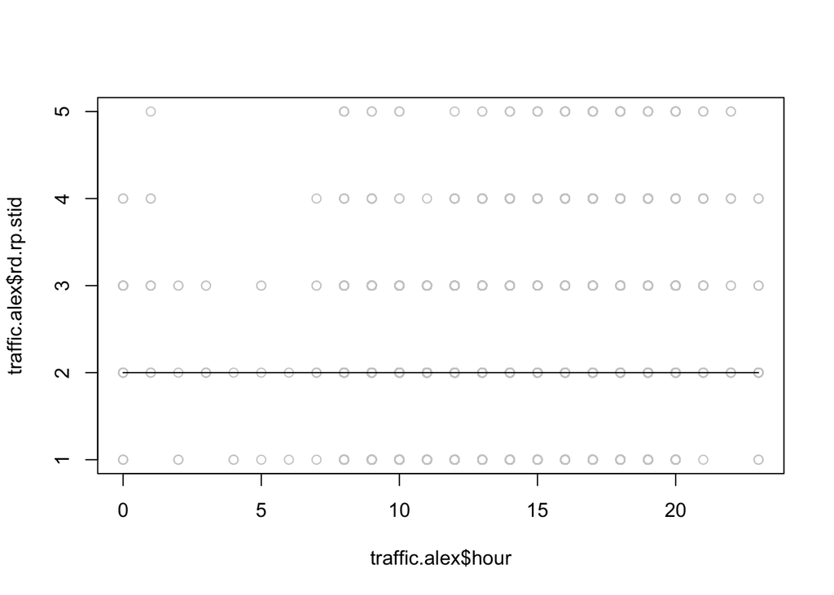

Traffic in cairo is similar to a bimodal distribution where the means can indicate the rush hours.

Let’s first define a heavy vs non-heavy traffic

```r
data.unq$report.is.za7ma <- data.unq$rd.rp.stid > 3 & data.unq$rd.rp.stid < 6
data.unq$report.is.mshza7ma <- data.unq$rd.rp.stid <= 3
data.unq$road.is.za7ma <- data.unq$rd.stid > 3 & data.unq$rd.stid < 6 & data.unq$rd.hr < 1
data.unq$road.is.mshza7ma <- data.unq$rd.stid <= 3 & data.unq$rd.hr < 1
```

Then we group by hour to see the number of heavy traffic reports vs non heavy.

```r
road.dist <- data.unq[, c("hour", "road.is.za7ma", "road.is.mshza7ma", "city", "report.is.za7ma", "report.is.mshza7ma")] %>%
filter(!is.na(road.is.za7ma)) %>% filter(!is.na(report.is.za7ma)) %>%
group_by(hour) %>%
summarize(za7ma=sum(road.is.za7ma), mshza7ma=sum(road.is.mshza7ma), za7ma.per=za7ma/mshza7ma,
         report.za7ma=sum(report.is.za7ma), report.mshza7ma=sum(report.is.mshza7ma),
         report.za7ma.per=report.za7ma/(report.za7ma + report.mshza7ma))
```

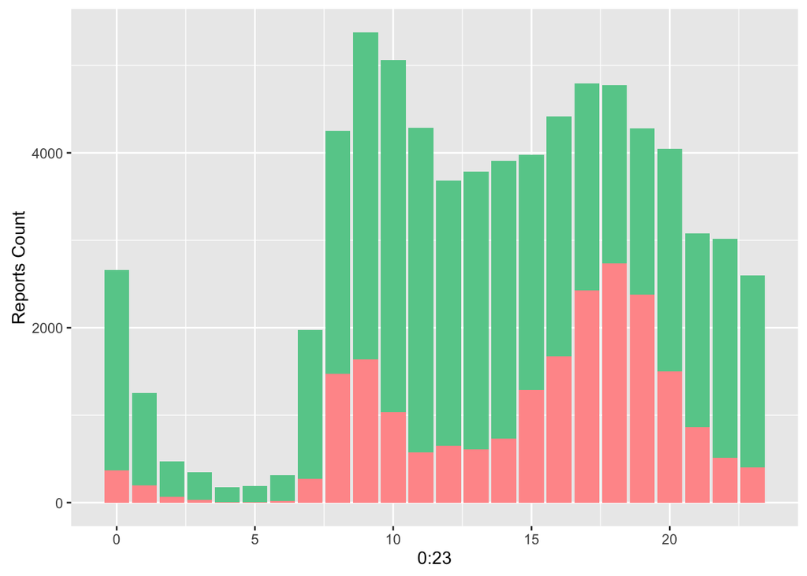

```r
p <- ggplot(data=road.dist) + ylab("Reports Count")
p <- p + geom_bar(aes(x=0:23, y=report.mshza7ma), fill="#66CC99", stat="identity" )
p <- p + geom_bar(aes(x=0:23, y=report.za7ma), fill="#FF9999", stat="identity")
p
```

If a road has traffic jam, many reports could be reporting this. Thus, let’s have a look on the road status. But we need to make sure that the last report was made less than one hour ago, which was done while setting the road status above.

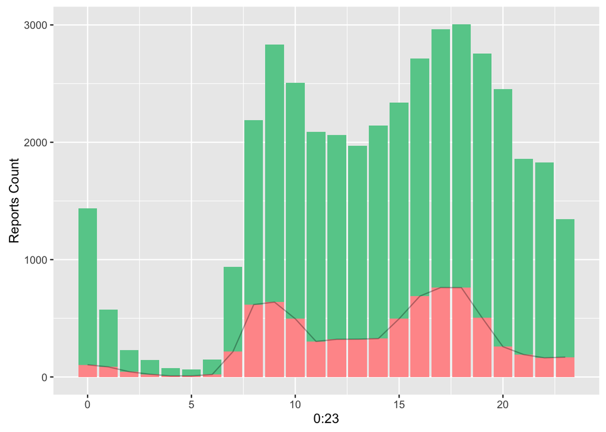

```r
p <- ggplot(data=road.dist) + ylab("Reports Count")
p <- p + geom_bar(aes(x=0:23, y=mshza7ma), fill="#66CC99", stat="identity")
p <- p + geom_bar(aes(x=0:23, y=za7ma), fill="#FF9999", stat="identity")
p <- p + geom_line(aes(x=0:23, y=za7ma, fill="black"), alpha=0.3)
p
```

Perfect. The road status follows the same bimodal pattern. But is this the case in all days?

Let’s draw the same plot for each weekday

```r
road.day.dist <- data.unq[, c("hour", "wday", "road.is.za7ma", "road.is.mshza7ma", "city", "report.is.za7ma", "report.is.mshza7ma")] %>%
filter(!is.na(road.is.za7ma)) %>% filter(!is.na(report.is.za7ma)) %>%
group_by(hour, wday) %>%
summarize(za7ma=sum(road.is.za7ma), mshza7ma=sum(road.is.mshza7ma), za7ma.per=za7ma/mshza7ma,
         report.za7ma=sum(report.is.za7ma), report.mshza7ma=sum(report.is.mshza7ma),
         report.za7ma.per=report.za7ma/(report.za7ma + report.mshza7ma))
```

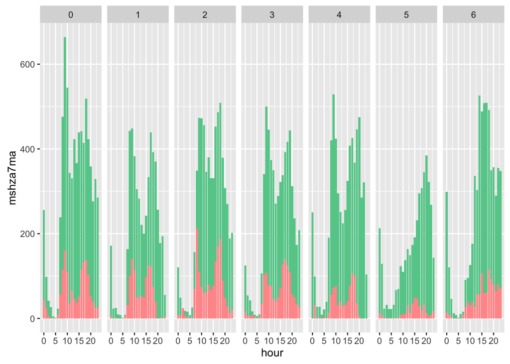

```r
p <- ggplot(data=road.day.dist)
p <- p + facet_grid(~wday)
p <- p + geom_bar(aes(x=hour, y=mshza7ma), fill="#66CC99", stat="identity")
p <- p + geom_bar(aes(x=hour, y=za7ma), fill="#FF9999", stat="identity")
p
```

We can see that all days follow the same distribution excepet for weekends.

We can confirm the distribution by checking the heavy traffic percentage out of all traffic reports.

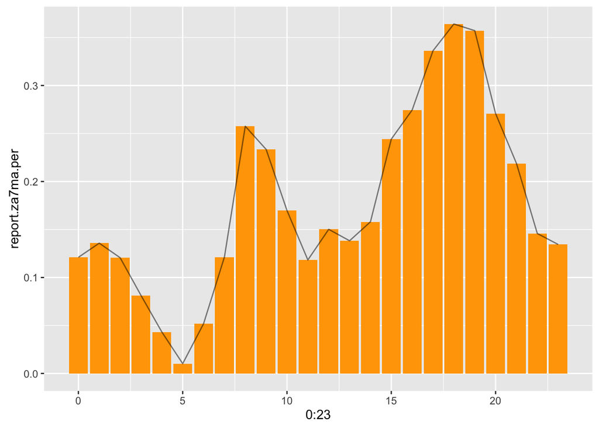

```r
p <- ggplot(data=road.dist)
p <- p + geom_bar(aes(x=0:23, y=report.za7ma.per), fill="orange", stat="identity")
p <- p + geom_line(aes(x=0:23, y=report.za7ma.per, fill="black"), alpha="0.5")
p
```

Now we can assume that the traffic follows a biomodal distriubiton.

Let’s focus on cairo and try to pick the two means (peaks) of the traffic by fitting a bimodal distribtuion.

```r
library(mixtools)
#Fit two Normals
dist = normalmixEM(data.unq$hour[!is.na(data.unq$rd.rp.stid) & data.unq$city=="cairo" & data.unq$rd.rp.stid > 3 & data.unq$rd.rp.stid < 6], lambda = 0.5)
```

```
## number of iterations= 99
```

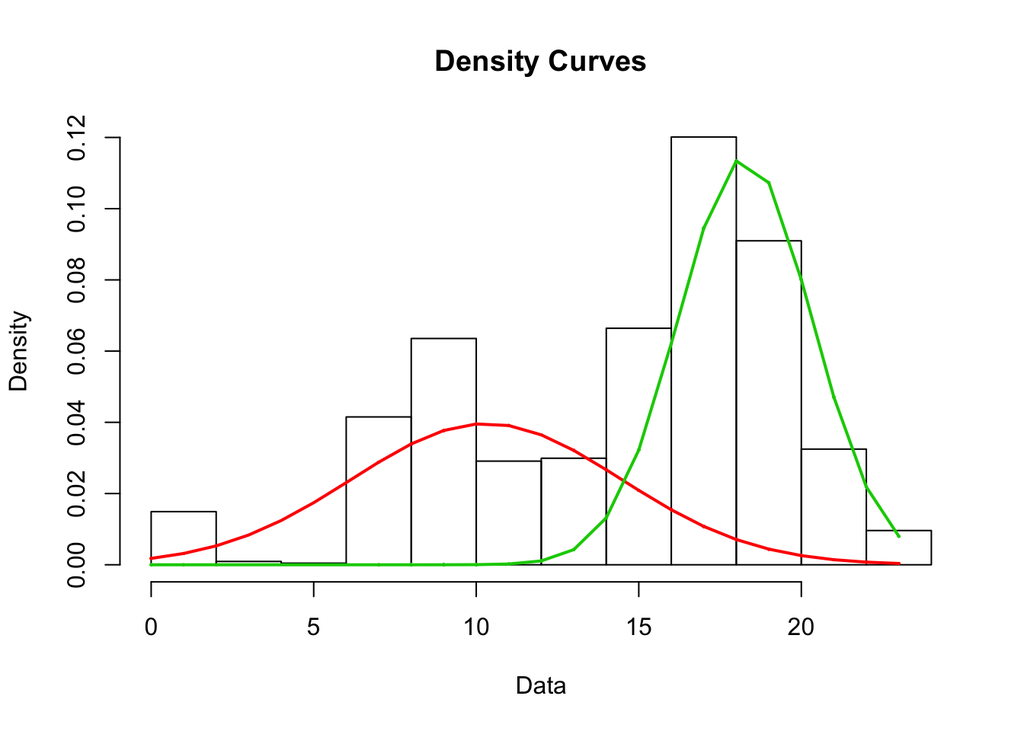

```r
plot(dist, density=TRUE, loglik=FALSE)
```

Thus the two means are

```r
dist$mu
```

```
## [1] 10.31149 18.26644
```

with standard deviation of

```r
dist$sigma
```

```
## [1] 4.142620 2.052138
```

Now let’s prove that average heavy traffic hour is different on weekdays from weekends

first, the mean and confidence level of the heavy traffic on weekdays

```r
road.day.dist$working.day <- road.day.dist$wday < 5
working.dist <- road.day.dist[road.day.dist$working.day == T,]
m <- weighted.mean(working.dist$hour, working.dist$za7ma)
N <- length(working.dist)
variance <- sum(working.dist$za7ma * ((working.dist$hour - m) ^ 2)) / ((sum(working.dist$za7ma) * (N- 1)) / N)
deviation <- sqrt(variance)
```

Mean and standard deviation

```r
paste(m, deviation)
```

```
## [1] "13.4764551994768 5.14259248620021"
```

Thus, the 95% confidence internval

```r
error <- qnorm(0.95)*deviation/sqrt(N)
left <- m - error
right <- m + error
```

```r
paste(left, right)
```

```
## [1] "10.6568512318568 16.2960591670967"
```

Let’s do the same for Weekends.

```r
road.day.dist$weekend <- road.day.dist$wday >= 5
weekend.dist <- road.day.dist[road.day.dist$weekend == T,]
m <- weighted.mean(weekend.dist$hour, weekend.dist$za7ma)
N <- length(weekend.dist)
variance <- sum(weekend.dist$za7ma * ((weekend.dist$hour - m) ^ 2)) / ((sum(weekend.dist$za7ma) * (N- 1)) / N)
deviation <- sqrt(variance)
```

```r
paste(m, deviation)
```

```
## [1] "15.8875530410184 5.26935346257028"
```

```r
error <- qnorm(0.95)*deviation/sqrt(N)
left <- m - error
right <- m + error
```

```r
paste(left, right)
```

```
## [1] "13.146707332316 18.6283987497208"
```

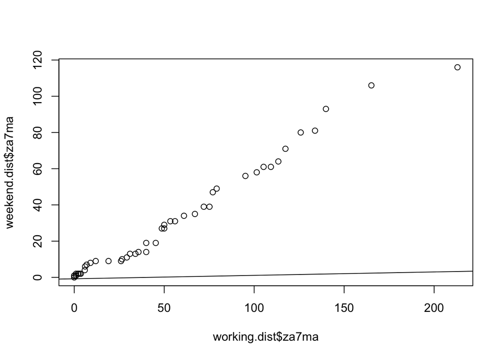

```r
qqplot(working.dist$za7ma, weekend.dist$za7ma); qqline(working.dist$za7ma, weekend.dist$za7ma)
```

### Accidents

Let’s have a look on how the accidents in Cairo look like.

```r
accidents.hour <- data.unq$hour[data.unq$city == "cairo" & data.unq$rd.rp.stid == 8]
accidents.hour <- na.omit(accidents.hour)
```

Accidents

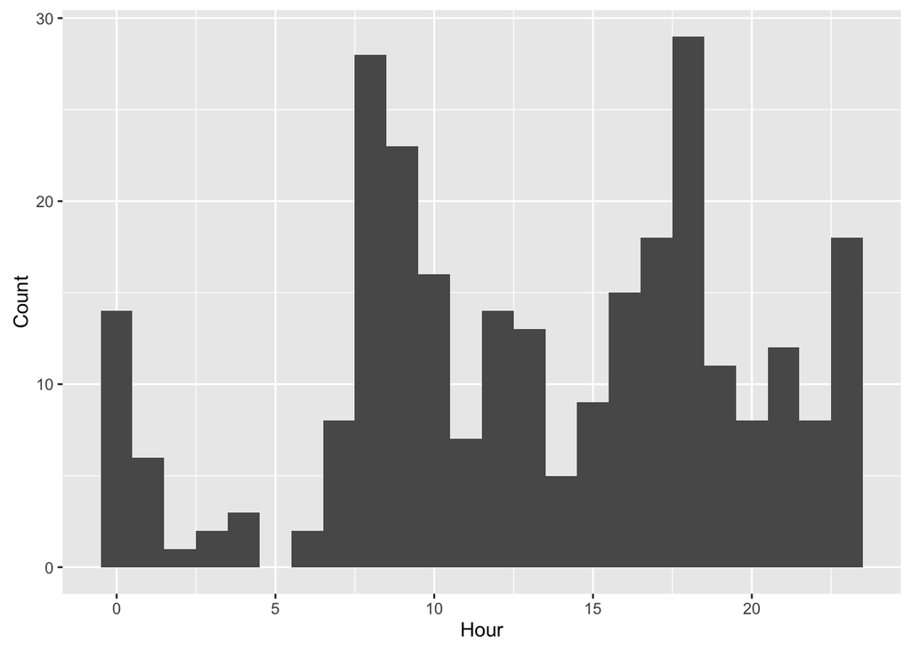

```r
qplot(accidents.hour, geom="histogram", binwidth=1, xlab = "Hour", ylab = "Count")
```

The distribution is similar to the bimodal distribution.

```r
dist = normalmixEM(accidents.hour, lambda = 0.5)
```

```
## number of iterations= 63
```

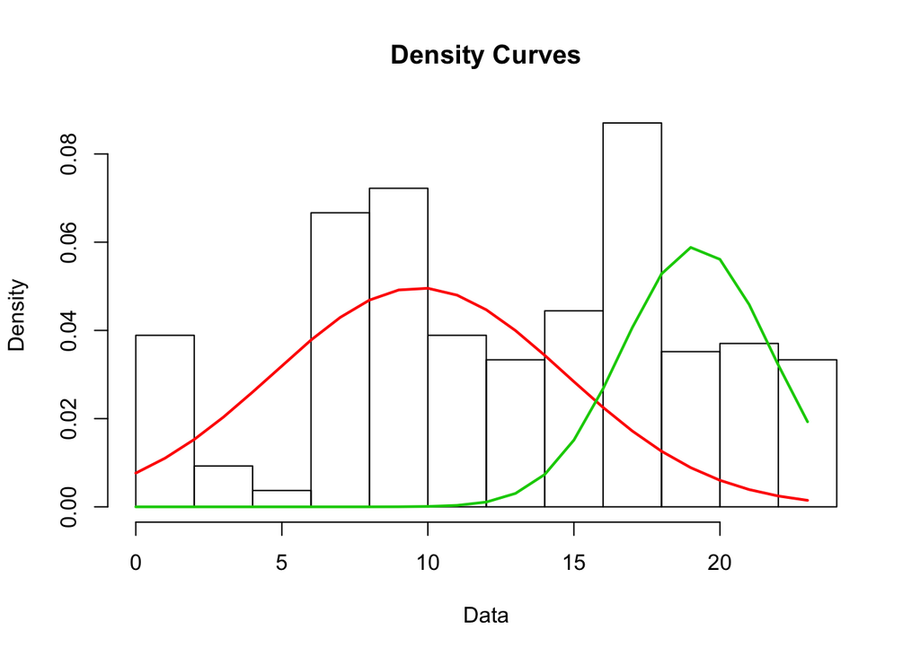

```r
plot(dist, density=TRUE, loglik=FALSE)
```

Means of Accidents Hour

```r
dist$mu
```

```
## [1]  9.697998 19.196041
```

Standard Deviation

```r
dist$sigma
```

```
## [1] 5.013862 2.543793
```

### Road names

Let’s see if we can use the road names to build a heatmap.

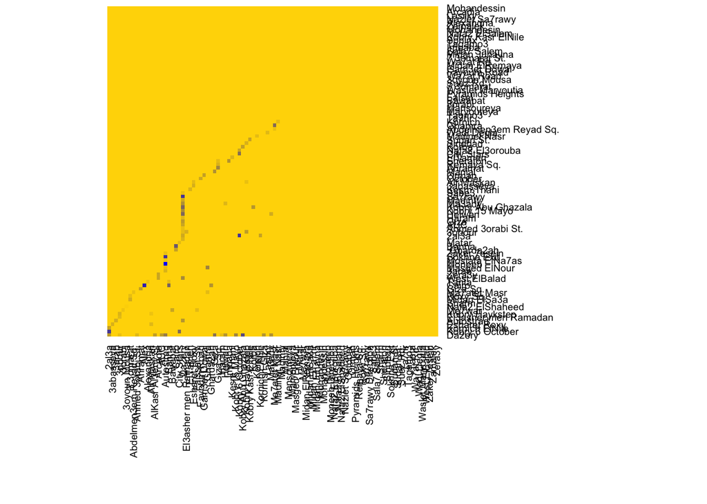

```r
library("igraph")
q <- data.unq %>% select(road.direction.from, road.direction.to, road.name, city) %>%
  filter(city == "cairo") %>% group_by(road.direction.to, road.direction.from) %>% summarize(count=length(road.name))

q <- q[complete.cases(q), ]

mat <- matrix(0, length(unique(q$road.direction.from)), length(unique(q$road.direction.to)))
rownames(mat) <- unique(q$road.direction.from)
colnames(mat) <- unique(q$road.direction.to)
f <- as.data.frame(mat)
for (i in 1:length(f)) {
  f[q$road.direction.from[i], q$road.direction.to[i]] <- q$count[i]
}
mat <- as.matrix(f)
palf <- colorRampPalette(c("gold", "blue"))
heatmap(mat, Rowv = NA, Colv = NA, col = palf(100), scale="none", margins=c(10,10) )
```

Road names are not well structured to build a graph from a map.

## Comments Analysis

Let’s see if there are significant comments people write when there is accidents.

```r
#ignore gps comments
data.unq$rd.rp.cm <- as.character(data.unq$rd.rp.cm)
cm.words <- as.factor(unlist(lapply(data.unq$rd.rp.cm[data.unq$rd.rp.nm != "bey2ollakgps"], function(s){strsplit(s, " ")})))
cm.words <- as.factor(unlist(lapply(data.unq$rd.rp.cm[data.unq$rd.rp.stid == 8], function(s){strsplit(s, " ")})))
cm.words.smpl <- cm.words[sample(500000)]
```

Show a sample of the most common words

```r
words.count <- tapply(as.factor(cm.words.smpl), as.factor(cm.words.smpl), FUN=length)
words.count <- sort(words.count, decreasing=T)
words.count %>% head(50)
```

```
##       7adsa          el 7adsa-حادثة                      في      الطريق
##          75          36          32          28          21          20
##         عند          .. 7adsa-حادثه         بعد          من 7adsa-7adsa
##          17          16          15          15          15          14
##         قبل       كوبري           و           w         نقل         على
##          14          12          12          11          10           9
##         علي         the           ف          نص  7adsa-حادث 7adsa-عربيه
##           9           8           8           8           7           7
##      الشمال       حادثة       عربية         قها 7adsa-عربية        ba3d
##           7           7           7           7           6           6
##      السلام        حالا          فى       كوبرى         لسه        مطلع
##           6           6           6           6           6           6
##        واقف    7adsa-من         abl          fe       kobry          mn
##           6           5           5           5           5           5
##       other          to         اول          بس        خبطت           ع
##           5           5           5           5           5           5
##       عربيه      مقلوبه
##           5           5
```

```r
m.words <- as.factor(unlist(lapply(data.unq$rd.rp.cm[data.unq$rd.rp.stid == 5], function(s){strsplit(s, " ")})))
cm.words.smpl <- cm.words[sample(5000000)]
words.count <- tapply(as.factor(cm.words.smpl), as.factor(cm.words.smpl), FUN=length)
words.count <- sort(words.count, decreasing=T)
words.count %>% head(50)
```

```
##       7adsa          el 7adsa-حادثة                      في      الطريق
##          75          36          32          28          21          20
##         عند          .. 7adsa-حادثه         بعد          من 7adsa-7adsa
##          17          16          15          15          15          14
##         قبل       كوبري           و           w         نقل         على
##          14          12          12          11          10           9
##         علي         the           ف          نص  7adsa-حادث 7adsa-عربيه
##           9           8           8           8           7           7
##      الشمال       حادثة       عربية         قها 7adsa-عربية        ba3d
##           7           7           7           7           6           6
##      السلام        حالا          فى       كوبرى         لسه        مطلع
##           6           6           6           6           6           6
##        واقف    7adsa-من         abl          fe       kobry          mn
##           6           5           5           5           5           5
##       other          to         اول          بس        خبطت           ع
##           5           5           5           5           5           5
##       عربيه      مقلوبه
##           5           5
```